# Hierarchical multinomial logistic regression models in Stan

```r
library("rstan")
library("ggplot2")
library("bayesplot")
library("dplyr")
library("tidyr")
```

```r
options(mc.cores = parallel::detectCores())
```

### Multinomial logit model review

Say you have responses on a survey that map to one choice out of $K$ unordered choices. We can model the probability of observing choice $i$ ($\text{Pr}(Y_i = j)$ like so:

$$\pi_{ij} = \dfrac{\exp(\eta_{ij})}{\sum_{j=1}^K \exp(\eta_{ij})}$$
where $\eta_{ij}$ are the log-odds of response $ij$. Note you can add a constant to all of the log-odds and get the same probability out. This is what we call a nonidentifiability and it is bad news. We can fix one of the categories to be unity, and this will identify the model. Our likelihood is now

$$\pi_{ij} = \dfrac{\exp(\eta_{ij})}{\sum_{j=1}^{K-1} \exp(\eta_{ij}) + 1}$$

There is a strong assumption in these models, namely the independence of irrelevant alternatives. It means that the probability of choosing between two alternatives (say, Hillary Clinton vs. Donald Trump) is not dependent on the characteristics of any other alternatives.

These models involve estimating $K-1$ simultaneous equations and can thus be computationally expensive. We’ll simulate some data to get a feel for fitting these models.

### Generate fake data

We haven’t done fake data generation and model checking yet, but this is an important part of modeling in Stan, especially when your models are complex.

$$y_n \sim \text{Categorical}(\text{softmax}(\alpha + \nu_n)) \\
\nu_n = X_n \times \beta, \, X_n \in \mathbb{R}^D, \, \beta \in \mathbb{R}^{D \times K - 1} \\
\beta_{d,k} \sim \text{Normal}(0, 1) \\
\alpha_{k} \sim \text{Normal}(0, 1)$$

```r
N <- 3000
K <- 3
D <- 3
X <- matrix(rnorm(N * D), N, D)
beta <- cbind(matrix(rnorm((K - 1) * D), D, K - 1),0)
alpha <- c(rnorm(K - 1), 0)
mu <- sweep(x = X %*% beta, MARGIN = 2, STATS = alpha, FUN = '+')
mu_soft <- t(apply(mu, 1, softmax))
y <- sapply(1:N, function(x) rmultinom(1, size = 1, prob = mu_soft[x,]))
y <- apply(y, 2, function(x) which(as.logical(x)))
```

```r
mod1 <- stan_model(file = 'mnl_constrained.stan')
```

[output not shown]

### Fit our model

```r
stan_dat <- list(y = y, N = N, D = D, X = X)
fit1 <- sampling(mod1, data = stan_dat, iter = 1000, seed =  349596)
```

### Inspect the model: convergence, effective sample size

```r
print(fit1)
```

```
## Inference for Stan model: mnl_constrained.
## 4 chains, each with iter=1000; warmup=500; thin=1;
## post-warmup draws per chain=500, total post-warmup draws=2000.
##
##                   mean se_mean   sd     2.5%      25%      50%      75%
## beta_raw[1,1]     2.04    0.00 0.10     1.85     1.98     2.04     2.10
## beta_raw[1,2]    -0.69    0.00 0.08    -0.85    -0.75    -0.69    -0.64
## beta_raw[1,3]    -0.59    0.00 0.06    -0.71    -0.63    -0.59    -0.55
## beta_raw[2,1]    -1.05    0.00 0.11    -1.27    -1.12    -1.05    -0.97
## beta_raw[2,2]     2.84    0.00 0.14     2.59     2.74     2.84     2.93
## beta_raw[2,3]    -0.76    0.00 0.07    -0.90    -0.81    -0.76    -0.71
## alpha_raw[1]      1.34    0.00 0.07     1.21     1.30     1.34     1.39
## alpha_raw[2]     -1.23    0.00 0.13    -1.50    -1.32    -1.23    -1.14
## beta[1,1]         2.04    0.00 0.10     1.85     1.98     2.04     2.10
## beta[1,2]        -0.69    0.00 0.08    -0.85    -0.75    -0.69    -0.64
## beta[1,3]        -0.59    0.00 0.06    -0.71    -0.63    -0.59    -0.55
## beta[2,1]        -1.05    0.00 0.11    -1.27    -1.12    -1.05    -0.97
## beta[2,2]         2.84    0.00 0.14     2.59     2.74     2.84     2.93
## beta[2,3]        -0.76    0.00 0.07    -0.90    -0.81    -0.76    -0.71
## beta[3,1]         0.00    0.00 0.00     0.00     0.00     0.00     0.00
## beta[3,2]         0.00    0.00 0.00     0.00     0.00     0.00     0.00
## beta[3,3]         0.00    0.00 0.00     0.00     0.00     0.00     0.00
## alpha[1]          1.34    0.00 0.07     1.21     1.30     1.34     1.39
## alpha[2]         -1.23    0.00 0.13    -1.50    -1.32    -1.23    -1.14
## alpha[3]          0.00    0.00 0.00     0.00     0.00     0.00     0.00
## lp__          -1547.42    0.06 1.93 -1551.88 -1548.54 -1547.12 -1546.03
##                  97.5% n_eff Rhat
## beta_raw[1,1]     2.23  1806    1
## beta_raw[1,2]    -0.54  1791    1
## beta_raw[1,3]    -0.47  2000    1
## beta_raw[2,1]    -0.83  1237    1
## beta_raw[2,2]     3.12  1427    1
## beta_raw[2,3]    -0.62  1714    1
## alpha_raw[1]      1.48  1571    1
## alpha_raw[2]     -0.96  1158    1
## beta[1,1]         2.23  1806    1
## beta[1,2]        -0.54  1791    1
## beta[1,3]        -0.47  2000    1
## beta[2,1]        -0.83  1237    1
## beta[2,2]         3.12  1427    1
## beta[2,3]        -0.62  1714    1
## beta[3,1]         0.00  2000  NaN
## beta[3,2]         0.00  2000  NaN
## beta[3,3]         0.00  2000  NaN
## alpha[1]          1.48  1571    1
## alpha[2]         -0.96  1158    1
## alpha[3]          0.00  2000  NaN
## lp__          -1544.57  1029    1
##
## Samples were drawn using NUTS(diag_e) at Mon Aug 14 16:16:46 2017.
## For each parameter, n_eff is a crude measure of effective sample size,
## and Rhat is the potential scale reduction factor on split chains (at
## convergence, Rhat=1).
```

### Check inferences vs. the true parameters

```r
post_draws_beta <- as.matrix(fit1,pars = c('beta'))
post_draws_alpha <- as.matrix(fit1,pars = c('alpha'))

print(colnames(post_draws_beta))
```

```
## [1] "beta[1,1]" "beta[2,1]" "beta[3,1]" "beta[1,2]" "beta[2,2]" "beta[3,2]"
## [7] "beta[1,3]" "beta[2,3]" "beta[3,3]"
```

```r
print(colnames(post_draws_alpha))
```

```
## [1] "alpha[1]" "alpha[2]" "alpha[3]"
```

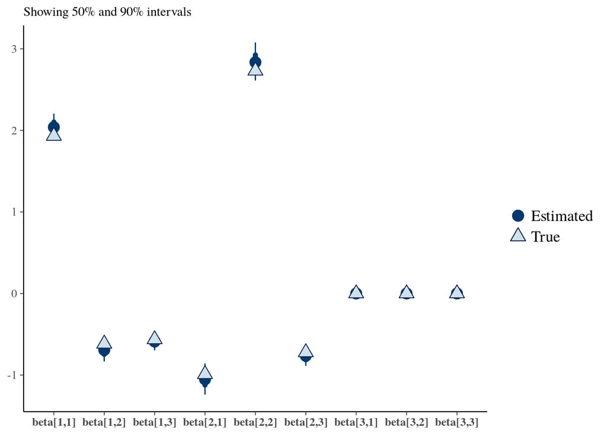

```r
true_beta <- c(as.vector(t(beta)))
mcmc_recover_intervals(post_draws_beta, true_beta)
```

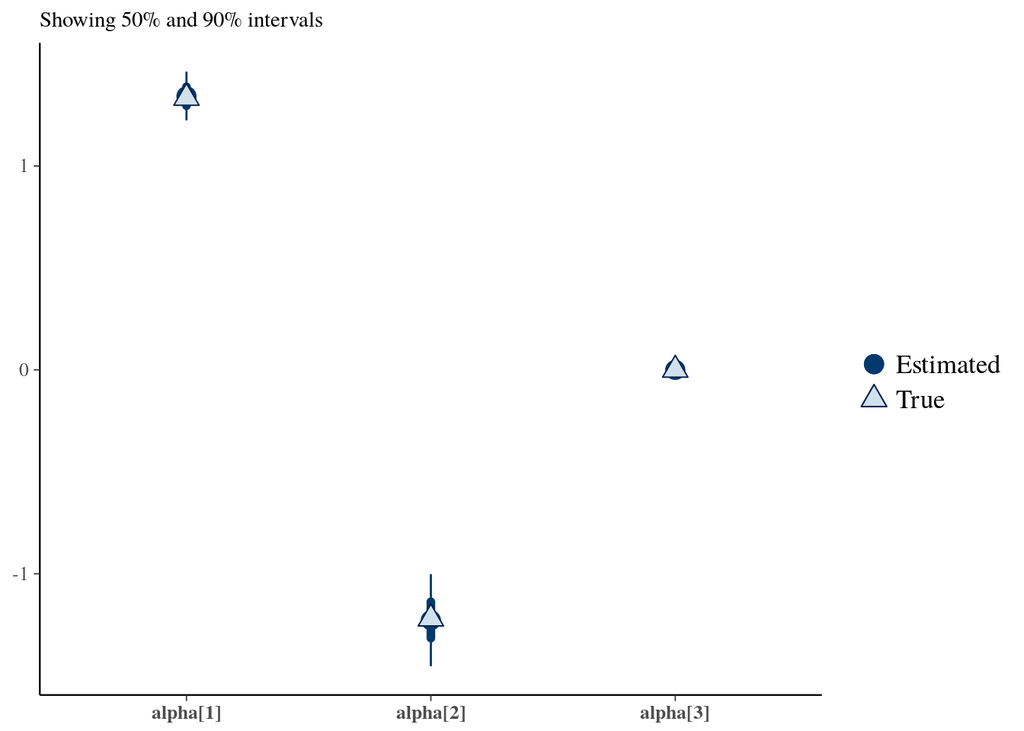

```r
mcmc_recover_intervals(post_draws_alpha, alpha)
```

### Hierarchical multinomial logit

Let’s generate some data from a hierarchical MNL model.

$$y_n \sim \text{Categorical}(\text{softmax}(\alpha +
\alpha^{\text{age}}_{[,\text{idx_age}[n]]} + \alpha^{\text{edu}}_{[,\text{idx_edu}[n]]} + \alpha^{\text{eth}}_{[,\text{idx_edu}[n]]} + \nu_n)) \\
\nu_n = X_n \times \beta \\
\alpha^{\text{age}}_{[k,]} = \sigma^\text{age}_{k} \times \eta^\text{age}_{[k,]},\,\,
\alpha^{\text{edu}}_{[k,]} = \sigma^\text{edu}_{k} \times \eta^\text{edu}_{[k,]}, \,\,
\alpha^{\text{eth}}_{[k,]} = \sigma^\text{eth}_{k} \times \eta^\text{eth}_{[k,]} \\
\alpha^\text{age} \in \mathbb{R}^{K - 1, \text{J_age}}, \ \alpha^\text{edu} \in \mathbb{R}^{K - 1, \text{J_edu}} \dots \\
\sigma^\text{age}, \sigma^\text{edu}, \sigma^\text{eth} \in \mathbb{R}^{K - 1} \\
\sigma^\text{age}_k = \tau^\text{age}_k \times \sigma^{\text{age}}_\text{inter_eqn}, \,
\sigma^\text{edu}_k = \tau^\text{edu}_k \times \sigma^{\text{edu}}_\text{inter_eqn}, \dots \\
\beta_{d,k} \sim \text{Normal}(0, 1) \\
\eta \sim \text{Normal}(0, 1) \\
\sigma^\text{age}_\text{inter_eqn}, \sigma^\text{edu}_\text{inter_eqn},
\sigma^\text{eth}_\text{inter_eqn} \sim \text{Normal}^+(0, 1) \\
\tau^\text{age}, \tau^\text{edu}, \tau^\text{eth} \sim \text{Normal}^+(0, 1)$$
### Generate fake data

```r
set.seed(123)
N <- 1000
K <- 3
D <- 3
J_age <- 5
J_eth <- 4
J_edu <- 5
G <- 3
X <- matrix(rnorm(N * D), N, D)
beta <- cbind(matrix(rnorm((K - 1) * D), D, K - 1),0)
alpha <- c(rnorm(K - 1), 0)
eta_age <- matrix(rnorm((K - 1) * J_age), K - 1, J_age)
eta_eth <- matrix(rnorm((K - 1) * J_eth), K - 1, J_eth)
eta_edu <- matrix(rnorm((K - 1) * J_edu), K - 1, J_edu)
alpha_age <- matrix(0, K, J_age)
alpha_eth <- matrix(0, K, J_eth)
alpha_edu <- matrix(0, K, J_edu)
sigma_age <- abs(rnorm(K - 1))
sigma_eth <- abs(rnorm(K - 1))
sigma_edu <- abs(rnorm(K - 1))
sigma_inter_eqn <- abs(rnorm(G))
for (k in 1:(K - 1)) {
  alpha_age[k,] <- sigma_inter_eqn[1] * sigma_age[k] * eta_age[k,]
  alpha_eth[k,] <- sigma_inter_eqn[2] * sigma_eth[k] * eta_eth[k,]
  alpha_edu[k,] <- sigma_inter_eqn[3] * sigma_edu[k] * eta_edu[k,]
}
alpha_age[K,] <- rep(0, J_age)
alpha_eth[K,] <- rep(0, J_eth)
alpha_edu[K,] <- rep(0, J_edu)

idx_age <- sample(J_age, N, replace = T)
idx_eth <- sample(J_eth, N, replace = T)
idx_edu <- sample(J_edu, N, replace = T)

mu <- sweep(x = X %*% beta, MARGIN = 2, STATS = alpha, FUN = '+')
mu <- t(t(mu) + alpha_age[, idx_age] + alpha_eth[, idx_eth] + alpha_edu[, idx_edu])
mu_soft <- t(apply(mu, 1, softmax))
y <- sapply(1:N, function(x) rmultinom(1, size = 1, prob = mu_soft[x,]))
y <- apply(y, 2, function(x) which(as.logical(x)))
```

### Compile and fit the model

```r
hier_mnl <- stan_model(file = 'mnl_constrained_hier.stan')
```

[output not shown]

```r
stan_dat <- list(N = N, K = K, D = D, G = G,
                 J_age = J_age, J_eth = J_eth, J_edu = J_edu,
                 idx_age = idx_age, idx_eth = idx_eth, idx_edu = idx_edu,
                 X = X)

fit_hier_mnl <- sampling(hier_mnl, data = stan_dat, iter = 1000)
```

### Examine the parameters

```r
print(fit_hier_mnl, pars = c('sigma_inter_eqn','sigma_age','sigma_edu','sigma_eth'))
```

```
## Inference for Stan model: mnl_constrained_hier.
## 4 chains, each with iter=1000; warmup=500; thin=1;
## post-warmup draws per chain=500, total post-warmup draws=2000.
##
##                    mean se_mean   sd 2.5%  25%  50%  75% 97.5% n_eff Rhat
## sigma_inter_eqn[1] 1.01    0.01 0.45 0.37 0.69 0.92 1.26  2.13  1632    1
## sigma_inter_eqn[2] 1.29    0.01 0.49 0.56 0.93 1.23 1.57  2.41  2000    1
## sigma_inter_eqn[3] 0.54    0.01 0.38 0.09 0.27 0.44 0.72  1.56  2000    1
## sigma_age[1]       1.33    0.01 0.54 0.53 0.93 1.25 1.65  2.60  2000    1
## sigma_age[2]       0.26    0.01 0.24 0.01 0.08 0.19 0.36  0.96  1625    1
## sigma_edu[1]       0.70    0.01 0.51 0.03 0.30 0.61 0.98  1.97  2000    1
## sigma_edu[2]       0.63    0.01 0.50 0.03 0.24 0.52 0.89  1.90  2000    1
## sigma_eth[1]       1.56    0.01 0.56 0.69 1.13 1.50 1.91  2.79  2000    1
## sigma_eth[2]       0.25    0.01 0.25 0.01 0.08 0.18 0.35  0.95  1114    1
##
## Samples were drawn using NUTS(diag_e) at Mon Aug 14 16:18:30 2017.
## For each parameter, n_eff is a crude measure of effective sample size,
## and Rhat is the potential scale reduction factor on split chains (at
## convergence, Rhat=1).
```

### Inspect inferences vs. true values

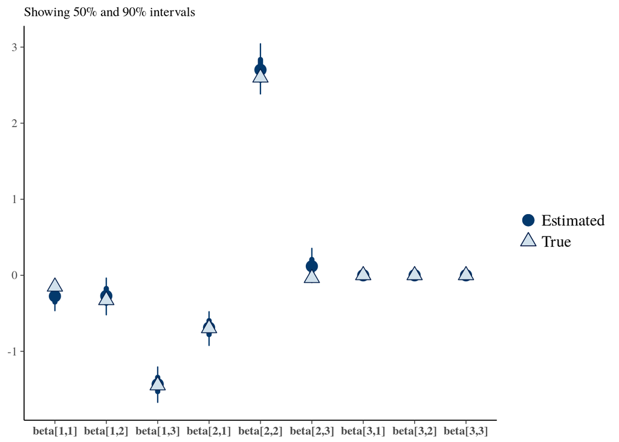

```r
post_draws_beta <- as.matrix(fit_hier_mnl, pars = c('beta'))

true <- as.vector(t(beta))
mcmc_recover_intervals(post_draws_beta, true)
```

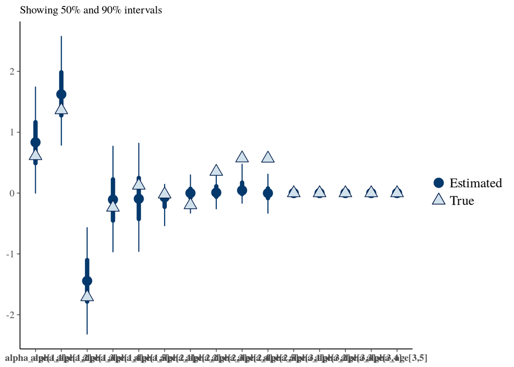

```r
post_draws_age <- as.matrix(fit_hier_mnl, pars = c('alpha_age'))

true <- as.vector(alpha_age)
mcmc_recover_intervals(post_draws_age, true)
```

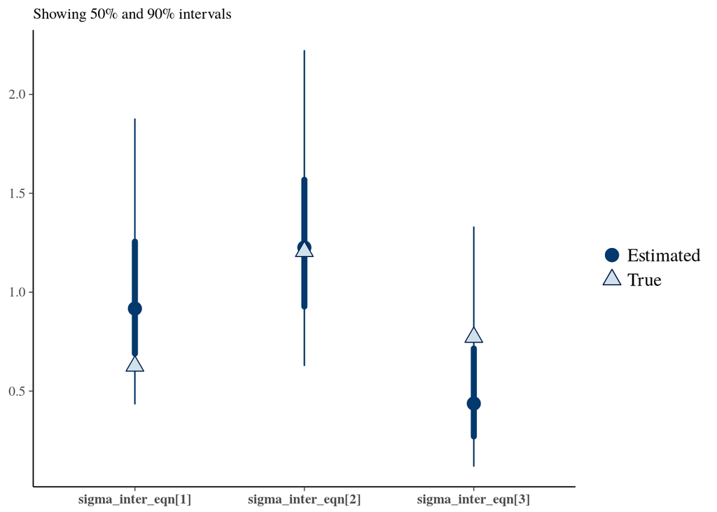

```r
post_draws_sigma_inter <- as.matrix(fit_hier_mnl, pars = c('sigma_inter_eqn'))

mcmc_recover_intervals(post_draws_sigma_inter, sigma_inter_eqn)
```

### Binning by cell

If we don’t have individual predictors, we can speed up our model by binning responses by cell. Here’s some individual level fake data that is binned up to the cell level below

```r
set.seed(123)
N <- 30000
K <- 6
D <- 3
J_age <- 5
J_eth <- 4
J_edu <- 5
G <- 3
alpha <- c(rnorm(K - 1), 0)
eta_age <- matrix(rnorm((K - 1) * J_age), K - 1, J_age)
eta_eth <- matrix(rnorm((K - 1) * J_eth), K - 1, J_eth)
eta_edu <- matrix(rnorm((K - 1) * J_edu), K - 1, J_edu)
age <- matrix(0, K, J_age)
eth <- matrix(0, K, J_eth)
edu <- matrix(0, K, J_edu)
sigma_age <- abs(rnorm(K - 1))
sigma_eth <- abs(rnorm(K - 1))
sigma_edu <- abs(rnorm(K - 1))
sigma_inter_eqn <- abs(rnorm(G))
for (k in 1:(K - 1)) {
  age[k,] <- sigma_inter_eqn[1] * sigma_age[k] * eta_age[k,]
  eth[k,] <- sigma_inter_eqn[2] * sigma_eth[k] * eta_eth[k,]
  edu[k,] <- sigma_inter_eqn[3] * sigma_edu[k] * eta_edu[k,]
}
age[K,] <- rep(0, J_age)
eth[K,] <- rep(0, J_eth)
edu[K,] <- rep(0, J_edu)

idx_age <- sample(J_age, N, replace = T)
idx_eth <- sample(J_eth, N, replace = T)
idx_edu <- sample(J_edu, N, replace = T)


mu <- t(age[, idx_age] + edu[, idx_edu] + eth[, idx_eth])
mu <- sweep(x = mu, MARGIN = 2, STATS = alpha, FUN = '+')
mu_soft <- t(apply(mu, 1, softmax))
y <- sapply(1:N, function(x) rmultinom(1, size = 1, prob = mu_soft[x,]))
y <- apply(y, 2, function(x) which(as.logical(x)))
mod_df <- data.frame(y = y,
                     idx_age = idx_age,
                     idx_edu = idx_edu,
                     idx_eth = idx_eth)
mod_df %>%
  group_by(
    idx_age, idx_edu, idx_eth, y
  ) %>%
  summarise(
    n = n()
  ) %>%
  group_by(
    idx_age, idx_edu, idx_eth
  ) %>%
  spread(
    key = y, value = n
  ) %>% ungroup() %>%
  mutate_at(
    .cols = vars(`1`,`2`,`3`),
    .funs = funs(if_else(is.na(.), 0L, .))
  ) -> cleaned_dat

N <- nrow(cleaned_dat)
idx_age <- cleaned_dat %>% .$idx_age
idx_eth <- cleaned_dat %>% .$idx_eth
idx_edu <- cleaned_dat %>% .$idx_edu
y <- cleaned_dat %>% select(`1`,`2`,`3`) %>% data.matrix()

stan_dat <- list(N = N, K = K, G = G,
                 J_age = J_age, J_eth = J_eth, J_edu = J_edu,
                 idx_age = idx_age, idx_eth = idx_eth, idx_edu = idx_edu,
                 y = y)
```

### Multinomial likelihood

When we bin by cell, we can use the multinomial likelihood to model the data rather than the categorical likelihood.

We’ll also need to use the softmax function, which is specialized in Stan.

### 2016 Election example

```r
polls <- readRDS('election_data.RDS')
```

Let’s modify our categorical logit model to have a state random intercept for state and get rid of the edu effect. We’ll have 3 equations and one reference category, which will be Jill Stein. We won’t add in yet.

$$y_n \sim \text{Multinomial}(\text{softmax}(\alpha +
\alpha^{\text{age}}_{[,\text{idx_age}[n]]} + \alpha^{\text{state}}_{[,\text{idx_state}[n]]})) \\
\alpha^{\text{age}}_{[k,]} = \sigma^\text{age}_{k} \times \eta^\text{age}_{[k,]},\,\,
\alpha^{\text{state}}_{[k,]} = \sigma^\text{state}_{k} \times \eta^\text{state}_{[k,]} \\
\alpha^\text{age} \in \mathbb{R}^{K - 1, \text{J_age}}, \ \alpha^\text{state} \in \mathbb{R}^{K - 1, \text{J_state}} \dots \\
\sigma^\text{age}, \sigma^\text{state} \in \mathbb{R}^{K - 1} \\
\sigma^\text{age}_k = \tau^\text{age}_k \times \sigma^{\text{age}}_\text{inter_eqn}, \,
\sigma^\text{state}_k = \tau^\text{state}_k \times \sigma^{\text{state}}_\text{inter_eqn}, \dots \\
\beta_{d,k} \sim \text{Normal}(0, 1) \\
\eta \sim \text{Normal}(0, 1) \\
\sigma^\text{age}_\text{inter_eqn}, \sigma^\text{state}_\text{inter_eqn} \sim \text{Normal}^+(0, 1) \\
\tau^\text{age}, \tau^\text{state} \sim \text{Normal}^+(0, 1)$$

```r
polls %>% ungroup() %>%
  mutate(
    idx_age = fac2int(age),
    idx_state = fac2int(state)
  ) -> polls
N <- nrow(polls)
idx_age <- polls %>% .$idx_age
idx_state <- polls %>% .$idx_state
J_age <- n_levels(idx_age)
J_state <- n_levels(idx_state)
y <- polls %>% select(Clinton, Trump, Johnson, Stein) %>% data.matrix()
K <- ncol(y)
```

```r
elec_mod <- stan_model('mnl_constrained_multinom_lik_election.stan')
```

[output not shown]

```r
stan_dat <- list(N = N, K = K, G = 2,
                 J_age = J_age, J_state = J_state,
                 idx_age = idx_age, idx_state = idx_state,
                 y = y)
elec_fit <- sampling(elec_mod, data = stan_dat, iter = 2000, seed = 3454542, chains = 4, cores = 4, control = list(max_treedepth = 15))
```

### Examine the fit

```r
print(elec_fit, pars = c('sigma_inter_eqn','alpha','sigma_age','sigma_state'))
```

```
## Inference for Stan model: mnl_constrained_multinom_lik_election.
## 4 chains, each with iter=2000; warmup=1000; thin=1;
## post-warmup draws per chain=1000, total post-warmup draws=4000.
##
##                     mean se_mean   sd  2.5%   25%  50%  75% 97.5% n_eff
## sigma_inter_eqn[1]  1.89    0.01 0.51  1.08  1.53 1.82 2.20  3.03  3328
## sigma_inter_eqn[2]  0.61    0.01 0.30  0.24  0.40 0.54 0.74  1.40  1559
## alpha[1]            0.02    0.02 1.00 -1.98 -0.67 0.04 0.71  1.98  4000
## alpha[2]           -0.01    0.02 1.02 -2.01 -0.72 0.00 0.69  1.95  4000
## alpha[3]            0.01    0.02 0.98 -1.83 -0.67 0.02 0.69  1.88  4000
## alpha[4]            0.00    0.00 0.00  0.00  0.00 0.00 0.00  0.00  4000
## sigma_age[1]        1.60    0.01 0.47  0.83  1.26 1.56 1.89  2.65  3575
## sigma_age[2]        1.56    0.01 0.49  0.78  1.20 1.50 1.85  2.69  3192
## sigma_age[3]        0.63    0.01 0.30  0.24  0.41 0.57 0.78  1.36  1996
## sigma_state[1]      0.67    0.01 0.29  0.23  0.45 0.62 0.84  1.34  2147
## sigma_state[2]      0.96    0.01 0.41  0.33  0.65 0.89 1.20  1.94  2141
## sigma_state[3]      0.85    0.01 0.37  0.29  0.57 0.79 1.07  1.69  2043
##                    Rhat
## sigma_inter_eqn[1]    1
## sigma_inter_eqn[2]    1
## alpha[1]              1
## alpha[2]              1
## alpha[3]              1
## alpha[4]            NaN
## sigma_age[1]          1
## sigma_age[2]          1
## sigma_age[3]          1
## sigma_state[1]        1
## sigma_state[2]        1
## sigma_state[3]        1
##
## Samples were drawn using NUTS(diag_e) at Mon Aug 14 16:26:25 2017.
## For each parameter, n_eff is a crude measure of effective sample size,
## and Rhat is the potential scale reduction factor on split chains (at
## convergence, Rhat=1).
```

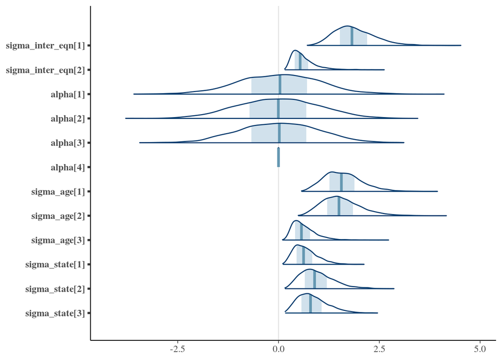

```r
post_draws <- rstan::extract(elec_fit, pars = c('sigma_inter_eqn','alpha','sigma_age','sigma_state'), permuted = FALSE)

mcmc_areas(post_draws)
```

How can we expand this model?